# k-means

Ramiro Casó

8/22/2020

### Intro

Este es un tutorial para explicarles cómo hacer agrupamientos utilizando el K-means.

Lo primero que debemos hacer es cargar las librerías que usaremos en el tutorial. En este caso, serán Dplyr, readxl y ggplot2.

```r
library(dplyr)
library(readxl)
library(ggplot2)
```

Seguidamente cargamos el set de datos. Lo haremos utilizando el data set de Ford Ka. Noten que cargué la hoja que ya tenía en mi working directory. En el comando de read_excel, específiqué la hoja que quería y, además, le quité las primeras 5 líneas, que no contienen información.

```r
psicograficos <- read_excel("DataSets/Ford_Ka_Students.xls",
    sheet = "Psychographic Data", skip = 5)
head(psicograficos)
```

```
## # A tibble: 6 x 63
##   `Respondent Num…    Q1    Q2    Q3    Q4    Q5    Q6    Q7    Q8    Q9   Q10
##              <dbl> <dbl> <dbl> <dbl> <dbl> <dbl> <dbl> <dbl> <dbl> <dbl> <dbl>
## 1                1     6     2     4     3     1     5     5     3     4     4
## 2                2     7     7     7     5     4     4     5     4     5     5
## 3                3     5     4     6     5     7     5     3     5     4     5
## 4                4     4     2     5     4     2     4     5     4     3     4
## 5                5     5     5     7     6     7     3     4     5     4     2
## 6                6     6     6     4     4     5     3     5     2     5     3
## # … with 52 more variables: Q11 <dbl>, Q12 <dbl>, Q13 <dbl>, Q14 <dbl>,
## #   Q15 <dbl>, Q16 <dbl>, Q17 <dbl>, Q18 <dbl>, Q19 <dbl>, Q20 <dbl>,
## #   Q21 <dbl>, Q22 <dbl>, Q23 <dbl>, Q24 <dbl>, Q25 <dbl>, Q26 <dbl>,
## #   Q27 <dbl>, Q28 <dbl>, Q29 <dbl>, Q30 <dbl>, Q31 <dbl>, Q32 <dbl>,
## #   Q33 <dbl>, Q34 <dbl>, Q35 <dbl>, Q36 <dbl>, Q37 <dbl>, Q38 <dbl>,
## #   Q39 <dbl>, Q40 <dbl>, Q41 <dbl>, Q42 <dbl>, Q43 <dbl>, Q44 <dbl>,
## #   Q45 <dbl>, Q46 <dbl>, Q47 <dbl>, Q48 <dbl>, Q49 <dbl>, Q50 <dbl>,
## #   Q51 <dbl>, Q52 <dbl>, Q53 <dbl>, Q54 <dbl>, Q55 <dbl>, Q56 <dbl>,
## #   Q57 <dbl>, Q58 <dbl>, Q59 <dbl>, Q60 <dbl>, Q61 <dbl>, Q62 <dbl>
```

### Normalización

Lo que sigue es normalizar los datos. Hay que dejar en la matriz de datos solo las columnas que usaremos para agrupar, de modo que hay que sacar la primera columna.

```r
norm_psico <- scale(psicograficos[,-1])
```

### Clustering

Seguidamente, empezamos a probar distintos clusters. Empecemos con K2

```r
k2=kmeans(norm_psico,2)
```

Veamos las membresías

```r
k2$cluster
```

```
##   [1] 1 2 2 1 2 2 2 2 1 1 2 2 1 1 2 1 2 1 2 1 2 2 2 2 2 1 2 1 1 1 2 2 1 1 2 2 2
##  [38] 2 2 1 2 1 2 1 2 2 1 1 2 1 1 1 2 2 1 1 1 2 2 2 1 1 2 1 1 2 2 2 1 2 2 1 1 2
##  [75] 2 1 1 2 1 1 2 2 2 2 2 2 1 2 1 2 1 1 2 1 2 2 1 1 2 1 2 2 2 2 1 2 1 2 2 2 2
## [112] 1 1 2 2 2 1 2 2 2 2 1 2 2 1 2 1 2 1 2 2 1 2 1 1 2 2 1 2 1 1 2 1 1 1 2 1 2
## [149] 2 2 2 1 2 2 2 1 2 2 1 1 1 2 2 2 2 2 2 2 2 1 2 1 2 2 2 2 1 1 2 2 1 1 2 1 2
## [186] 2 2 2 1 1 2 2 2 2 2 2 1 1 1 1 2 1 2 1 1 2 1 1 1 2 1 2 1 1 1 2 2 1 1 2 2 2
## [223] 2 2 2 2 2 1 1 1 1 1 1 1 2 1 1 2 2 1 1 2 2 1 2 2 2 1 2 2
```

Veamos los centroides

```r
k2$centers
```

```
##           Q1         Q2         Q3         Q4         Q5          Q6
## 1 -0.2413421 -0.8197727 -0.3879569 -0.5692846 -0.7830895  0.02563333
## 2  0.1805847  0.6133963  0.2902894  0.4259682  0.5859481 -0.01918019
##            Q7            Q8          Q9         Q10          Q11          Q12
## 1 -0.05959071 -1.125489e-04 -0.04041168 -0.03619340 -0.011272533  0.010672563
## 2  0.04458885  8.421492e-05  0.03023811  0.02708177  0.008434693 -0.007985764
##           Q13        Q14        Q15        Q16        Q17        Q18        Q19
## 1 -0.04661848  0.9568289  0.8901652  0.5921163  0.9372114  0.5942913  0.6074743
## 2  0.03488236 -0.7159489 -0.6660677 -0.4430520 -0.7012701 -0.4446795 -0.4545437
##          Q20        Q21        Q22        Q23         Q24        Q25        Q26
## 1  0.8005130  0.8710725  0.8753576 -0.7984887 -0.02375309 -0.9010950 -0.8541464
## 2 -0.5989853 -0.6517815 -0.6549879  0.5974706  0.01777329  0.6742459  0.6391166
##          Q27        Q28        Q29        Q30        Q31        Q32        Q33
## 1 -0.5806311 -0.8749025 -0.5558236 -0.5781547  0.2977006 -0.3752446 -0.4262760
## 2  0.4344583  0.6546473  0.4158960  0.4326053 -0.2227550  0.2807774  0.3189617
##          Q34        Q35        Q36         Q37        Q38        Q39        Q40
## 1 -0.3717443 -0.4287214 -0.4177455 -0.01552838 -0.3676184  0.3835858  0.3750989
## 2  0.2781583  0.3207915  0.3125788  0.01161914  0.2750711 -0.2870188 -0.2806684
##          Q41         Q42        Q43        Q44        Q45        Q46        Q47
## 1 -0.3366881  0.07456546  0.4486609 -0.1415085 -0.5046888 -0.4777561 -0.6147888
## 2  0.2519275 -0.05579374 -0.3357113  0.1058840  0.3776343  0.3574818  0.4600168
##          Q48        Q49        Q50        Q51        Q52        Q53        Q54
## 1 -0.4816946 -0.4785828 -0.4797348  0.5847159  0.6972978  0.7055274  0.5780356
## 2  0.3604288  0.3581004  0.3589624 -0.4375147 -0.5217543 -0.5279121 -0.4325161
##          Q55        Q56        Q57        Q58        Q59        Q60        Q61
## 1  0.5785220  0.5262789  0.3758655  0.3026818  0.3676517 -0.2552567 -0.4463421
## 2 -0.4328801 -0.3937891 -0.2812420 -0.2264822 -0.2750960  0.1909963  0.3339762
##          Q62
## 1 -0.3658248
## 2  0.2737290
```

Y finalmente, veamos el tamaño de cada uno

```r
k2$size
```

```
## [1] 107 143
```

Ahora que ya vimos como se hace, paso a paso, probemos con K=4, pero hagámoslo todo en un mismo chunk de código.

```r
k4=kmeans(norm_psico,4)
k4$cluster
```

```
##   [1] 2 3 2 2 2 3 4 3 1 2 3 2 1 2 4 2 4 2 4 1 2 2 4 2 2 1 2 2 2 2 2 3 2 2 2 2 2
##  [38] 2 4 2 3 2 2 2 2 2 2 2 2 2 2 1 2 2 1 1 2 2 4 2 2 2 3 2 1 2 3 4 2 3 3 2 1 2
##  [75] 3 2 2 2 2 2 3 2 4 3 2 3 2 3 1 2 2 1 2 2 2 3 2 2 4 1 2 2 2 3 1 4 2 2 4 4 2
## [112] 1 2 4 3 2 2 3 3 3 4 2 3 2 1 2 2 4 2 2 2 1 4 1 2 4 2 2 2 2 2 4 2 2 1 2 1 3
## [149] 4 3 4 2 4 3 4 1 3 4 2 2 2 2 4 4 3 3 3 2 4 1 3 1 4 3 2 3 2 2 2 2 1 2 2 1 2
## [186] 3 2 2 2 2 2 2 4 3 2 2 1 2 2 2 2 2 2 1 2 2 2 2 1 3 2 4 1 2 2 2 3 2 2 3 2 4
## [223] 2 3 4 4 4 1 2 2 2 2 1 2 2 2 2 4 4 1 2 4 2 2 3 4 2 1 2 3
```

```r
k4$centers
```

```
##           Q1         Q2         Q3         Q4          Q5         Q6
## 1  0.9106563 -0.2530945 -0.5141600 -1.6791522  0.04878010  0.2177599
## 2 -0.7201618 -0.6373693  0.3593052  0.4557348 -0.06119897 -0.0403348
## 3  0.9757031  1.2031526 -0.4414289 -0.1141529  0.16459876 -0.1603789
## 4  0.8593035  1.2948583 -0.4261171 -0.1448392  0.01113007  0.1340450
##             Q7          Q8          Q9         Q10         Q11         Q12
## 1 -0.328643723 -0.07250729 -0.16942262 -0.16023607  0.01498337 -0.17358561
## 2 -0.008872271  0.10580401 -0.04938635 -0.03612896 -0.05859567  0.07502322
## 3  0.952290472 -0.49274850 -0.20943471  0.15347913 -0.05525117  0.04670070
## 4 -0.692971099  0.18993714  0.54507898  0.10648535  0.26142033 -0.17938261
##           Q13        Q14        Q15        Q16        Q17        Q18        Q19
## 1 -0.12588255  1.1185832  1.1305668 -0.4968309  1.0772087 -0.5084489 -0.3096441
## 2  0.06657220  0.4428583  0.1569907  0.3628185 -0.1336132  0.3932293  0.3680167
## 3  0.01047203 -1.2240151 -0.8863985 -0.4364231 -0.1032120 -0.4299561 -0.6569707
## 4 -0.15028284 -1.2851112 -0.5973921 -0.4589232 -0.3062198 -0.5679868 -0.4035500
```

[output cut: 35 more lines]

```r
k4$size
```

```
## [1]  32 140  40  38
```

Como vamos a quedarnos con 4 clusters, lo que corresponde ahora es agregar la columna de membresías al dataset origial, para después proceder con los análisis descriptivos correspondientes. Noten que se cambió el nivel de medida de la variable membresía para hacerla un factor, que R reconoce como una variable categórica.

```r
clusters <-k4$cluster
psicograficos$membresia <-as.factor(clusters)
glimpse(psicograficos)
```

```
## Observations: 250
## Variables: 64
## $ `Respondent Number` <dbl> 1, 2, 3, 4, 5, 6, 7, 8, 9, 10, 11, 12, 13, 14, 15…
## $ Q1                  <dbl> 6, 7, 5, 4, 5, 6, 7, 6, 6, 6, 7, 4, 7, 4, 6, 4, 6…
## $ Q2                  <dbl> 2, 7, 4, 2, 5, 6, 7, 7, 4, 2, 7, 5, 4, 2, 6, 2, 7…
## $ Q3                  <dbl> 4, 7, 6, 5, 7, 4, 3, 3, 6, 4, 2, 6, 4, 5, 3, 1, 4…
## $ Q4                  <dbl> 3, 5, 5, 4, 6, 4, 3, 4, 1, 5, 4, 7, 1, 4, 3, 1, 4…
## $ Q5                  <dbl> 1, 4, 7, 2, 7, 5, 5, 5, 3, 1, 6, 6, 3, 1, 3, 2, 5…
## $ Q6                  <dbl> 5, 4, 5, 4, 3, 3, 4, 3, 4, 5, 5, 4, 5, 4, 5, 4, 4…
## $ Q7                  <dbl> 5, 5, 3, 5, 4, 5, 4, 4, 4, 3, 6, 3, 4, 5, 3, 3, 3…
## $ Q8                  <dbl> 3, 4, 5, 4, 5, 2, 4, 3, 4, 4, 5, 5, 4, 4, 5, 3, 5…
## $ Q9                  <dbl> 4, 5, 4, 3, 4, 5, 4, 5, 3, 5, 3, 5, 5, 3, 4, 2, 4…
## $ Q10                 <dbl> 4, 5, 5, 4, 2, 3, 3, 3, 4, 3, 6, 4, 4, 3, 2, 4, 5…
## $ Q11                 <dbl> 4, 4, 5, 4, 5, 4, 7, 4, 4, 4, 3, 5, 3, 4, 3, 3, 2…
## $ Q12                 <dbl> 5, 4, 5, 4, 4, 4, 4, 4, 3, 5, 5, 3, 4, 3, 4, 4, 4…
```

[output cut: 51 more lines]

Por último, un sencillo gráfico como el que usaríamos para analizar cada uno de los items por cluster.

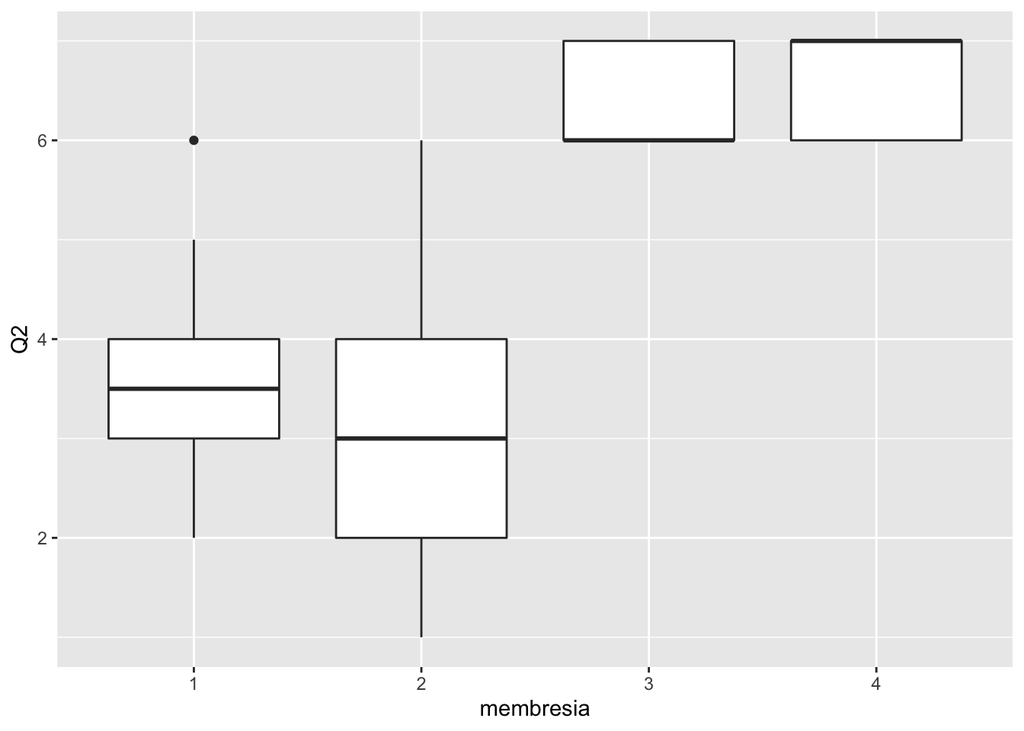

```r
ggplot(psicograficos, aes(x=membresia, y=Q2)) + geom_boxplot()
```